# ECON90080 - Assignment 2

Josh Copeland

2025-10-01

```r
# Libraries used:

# library(tidyverse)
# library(lubridate)
# library(quantmod)
```

# Question 1

### (a)

Download quarterly data from FRED on real GDP (A191RA3Q086SBEA), real durables consumption (DDURRA3M086SBEA), real non-durable consumption (DNDGRA3M086SBEA) and real services consumption (DSERRA3Q086SBEA) for 1960q1 - 2025q1. Take natural logs of each series and first difference it to make it stationary. Plot how each consumption spending category varies with GDP. State how each series co-moves with GDP.

Answer:

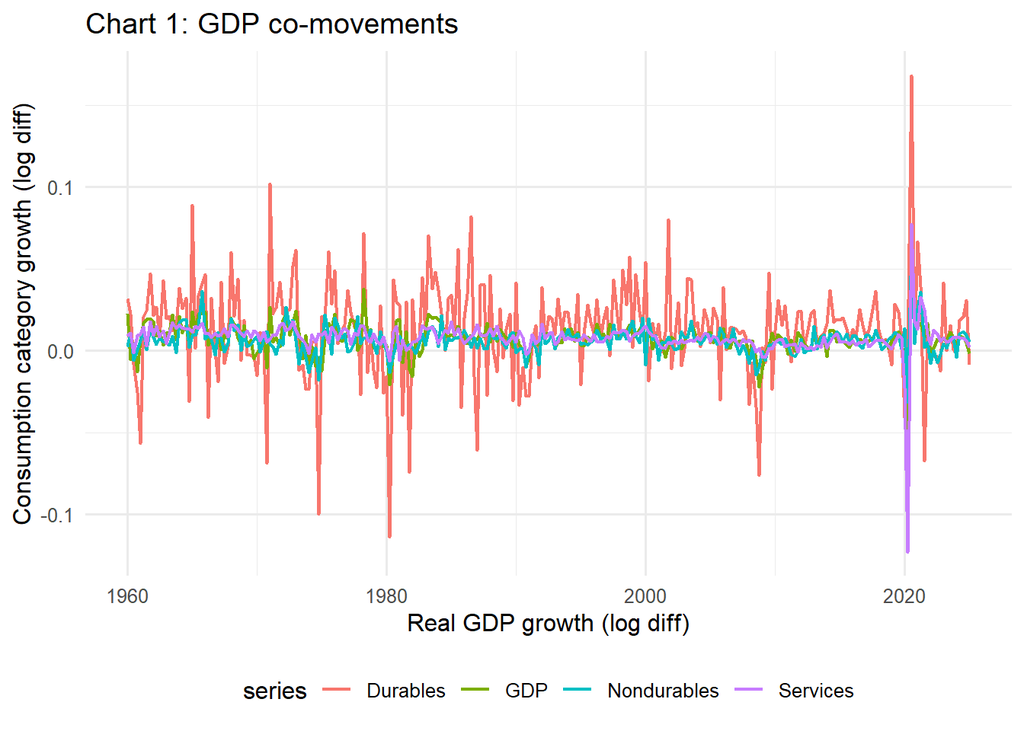

```r
# Map FRED IDs to tidy names
fred_ids <- tribble(
  ~id,                  ~series,
  "A191RA3Q086SBEA",    "GDP (real, Q)",
  "DDURRA3M086SBEA",    "Consumption: Durables (real, M)",
  "DNDGRA3M086SBEA",    "Consumption: Nondurables (real, M)",
  "DSERRA3Q086SBEA",    "Consumption: Services (real, Q)"
)

# 1) Download all series and stack
raw_long <- fred_ids$id %>%
  map_dfr(~{
    xt <- getSymbols(.x, src = "FRED", auto.assign = FALSE)
    tibble(date = as.Date(index(xt)), value = as.numeric(xt[,1]), id = .x)
  }) %>%
  left_join(fred_ids, by = "id")

# 2) Convert to quarterly (monthly → quarterly mean), then log-diff per series
g_long <- raw_long %>%
  mutate(qtr = floor_date(date, "quarter")) %>%
  group_by(series, qtr) %>%
  summarize(val_q = mean(value, na.rm = TRUE), .groups = "drop_last") %>%
  arrange(series, qtr) %>%
  mutate(g = log(val_q) - lag(log(val_q))) %>%   # quarterly log growth
  ungroup() %>%
  filter(qtr >= ymd("1960-01-01"), qtr <= ymd("2025-03-31")) %>%
  drop_na(g)

# 3) Make a wide table of growth just once (for plotting + stats)
g_wide <- g_long %>%
  select(series, qtr, g) %>%
  pivot_wider(names_from = series, values_from = g) %>%
  rename(
    gdp_g   = `GDP (real, Q)`,
    dur_g   = `Consumption: Durables (real, M)`,
    nond_g  = `Consumption: Nondurables (real, M)`,
    serv_g  = `Consumption: Services (real, Q)`
  )

# 4) Plot: each consumption category vs GDP growth
plot_df_ts <- g_wide %>%
  select(qtr, gdp_g, dur_g, nond_g, serv_g) %>%
  pivot_longer(-qtr, names_to = "series", values_to = "growth") %>%
  mutate(series = recode(series,
                         gdp_g  = "GDP",
                         dur_g  = "Durables",
                         nond_g = "Nondurables",
                         serv_g = "Services"))


ggplot(plot_df_ts, aes(x = qtr, y = growth, color = series)) +
  geom_line(linewidth = 0.8) +
  labs(
    title = "Chart 1: GDP co-movements",
    x = "Real GDP growth (log diff)",
    y = "Consumption category growth (log diff)"
  ) +
  theme_minimal(base_size = 12) +
  theme(legend.position = "bottom")
```

### (b)

Compute the standard deviation of each series. What can you say about the volatility of each consumption spending category relative to GDP? Provide some intuition.

Answer:

- The vol_stats table below indicates incurables is almost three times as volatile as GDP, reflecting the fact household are able to more easily delay the purchases of durables - it is not a necessity.
- Services and nondurables are much steadier, with volatility close to or below GDP, reflecting these categories cover necessities (such as groceries) which households cannot delay.

```r
# Compute standard deviations of growth rates
vol_stats <- g_wide %>%
  select(gdp_g, dur_g, nond_g, serv_g) %>%
  summarise(across(everything(), \(x) sd(x, na.rm = TRUE))) %>%
  pivot_longer(everything(), names_to = "series", values_to = "sd") %>%
  mutate(series = recode(series,
                         gdp_g  = "GDP",
                         dur_g  = "Durables",
                         nond_g = "Nondurables",
                         serv_g = "Services")) %>%
  arrange(desc(sd))

vol_stats
```

```
## # A tibble: 4 × 2
##   series           sd
##   <chr>         <dbl>
## 1 Durables    0.0302
## 2 GDP         0.0106
## 3 Services    0.0106
## 4 Nondurables 0.00848
```

### (c)

Calculate cross-correlations of each consumption spending category with GDP for lags 0,1,2 and 3.Which series is the leading indicator of GDP? [Note if a lagged series has high correlation with contemporaneous GDP, this series leads GDP because past values of this series lead the turning points in GDP.]

Answer:

- All three categories of consumption given move closely with GDP, with services showing the stronges contemporaneous correlation. All the correlations at lags 1-3 are much weaker, meaning consumption generally moves with GDP rather than ahead of it.

```r
lags <- 0:3

# Compute cross-correlations in matrix form
xcor_mat <- g_wide %>%
  select(qtr, gdp_g, dur_g, nond_g, serv_g) %>%
  pivot_longer(c(dur_g, nond_g, serv_g),
               names_to = "series", values_to = "cons_g") %>%
  group_by(series) %>%
  group_modify(~{
    map_dfr(lags, function(L) tibble(
      lag = L,
      corr = cor(dplyr::lag(.x$cons_g, L), .x$gdp_g, use = "complete.obs")
    ))
  }) %>%
  ungroup() %>%
  pivot_wider(names_from = lag, values_from = corr,
              names_prefix = "lag_")

xcor_mat
```

```
## # A tibble: 3 × 5
##   series lag_0   lag_1  lag_2  lag_3
##   <chr>  <dbl>   <dbl>  <dbl>  <dbl>
## 1 dur_g  0.550  0.257  0.117  0.0526
## 2 nond_g 0.615  0.0719 0.232  0.0635
## 3 serv_g 0.724 -0.0413 0.0170 0.0532
```

```r
write_csv(xcor_mat, "xcor_mat.csv")
```

# Question 2

Download monthly data from FRED on the unemployment rate (UNRATE), the level of unemployed (UNEMPLOY), the level of vacancies (JTSJOL), the level of hires (JTSHIL) , and the total separation rate (JTSTSR) for the period covering 2001m1-2025m7.

### (a)

- Consider the matching function we discussed in class $M(U_t, V_t) = \xi \frac{U_t V_t}{\left(U_t^{\alpha} + V_t^{\alpha}\right)^{1/\alpha}}$ where $\xi$ is the matching efficiency paramter and $\alpha$ is the elasticity o the mathcing function with respect the unemployment rate and $0<\alpha<1$. Denote $\theta=V_t/U_t$ and given this matching function, write down an expression for the job-finding rate $p(\theta_t)$ in terms of $\theta_t$ and parameters of the matching function.

### (b)

Assuming $\xi=2.9$ abd $\alpha=0.5$. Given data on the lvel of unemployed and vacancies, compute the job-finding rate, $p(\theta_t)$

```r
# Parameters
xi    <- 2.9
alpha <- 0.5

p_of_theta <- function(theta, xi, alpha) {
  xi * theta / (1 + theta^alpha)^(1/alpha)
}

# Get series separately
getSymbols("UNEMPLOY", src = "FRED", auto.assign = TRUE)
```

```
## [1] "UNEMPLOY"
```

```r
getSymbols("JTSJOL",   src = "FRED", auto.assign = TRUE)
```

```
## [1] "JTSJOL"
```

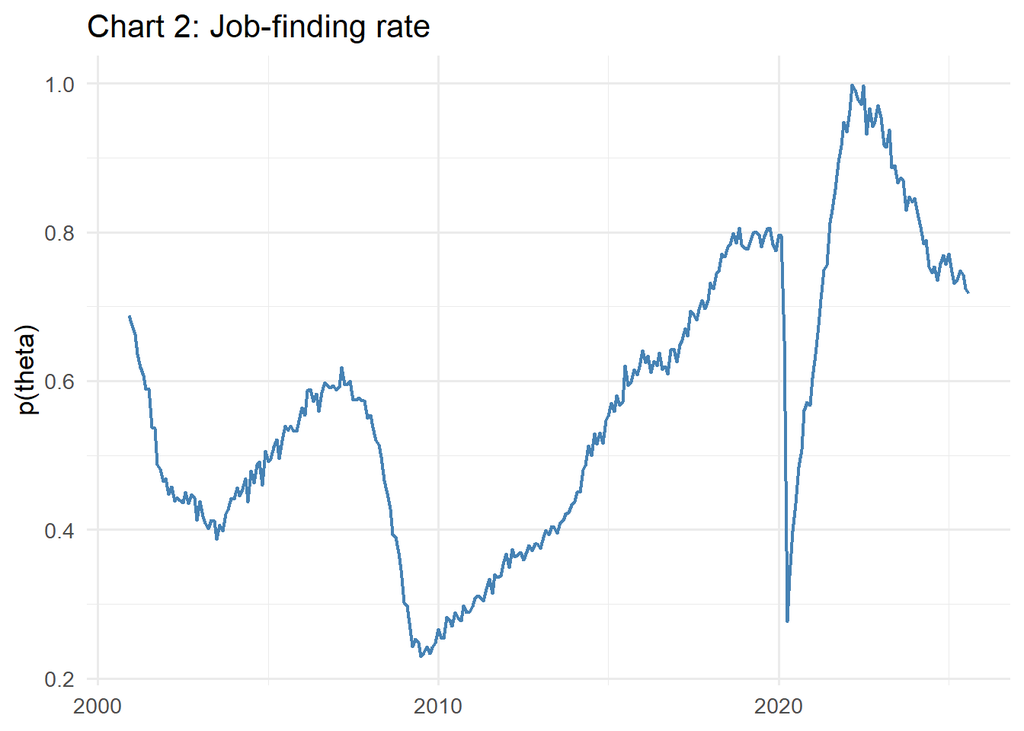

```r
# Convert xts objects to tibbles with dates
unemp_df <- data.frame(date = index(UNEMPLOY), UNEMPLOY = as.numeric(UNEMPLOY))
jolts_df <- data.frame(date = index(JTSJOL),   JTSJOL   = as.numeric(JTSJOL))

# Join and compute variables
df <- inner_join(unemp_df, jolts_df, by = "date") %>%
  filter(!is.na(UNEMPLOY), !is.na(JTSJOL), UNEMPLOY > 0) %>%
  mutate(
    theta = JTSJOL / UNEMPLOY,
    p     = p_of_theta(theta, xi, alpha)
  )

# Plot
ggplot(df, aes(x = date, y = p)) +
  geom_line(color = "steelblue", linewidth = 0.8) +
  labs(
    title = "Chart 2: Job-finding rate",
    x = NULL, y = "p(theta)"
  ) +
  theme_minimal(base_size = 13)
```

```r
# Download required FRED series
getSymbols(c("UNRATE", "JTSTSR", "UNEMPLOY", "JTSJOL"), src = "FRED")
```

```
## [1] "UNRATE"   "JTSTSR"   "UNEMPLOY" "JTSJOL"
```

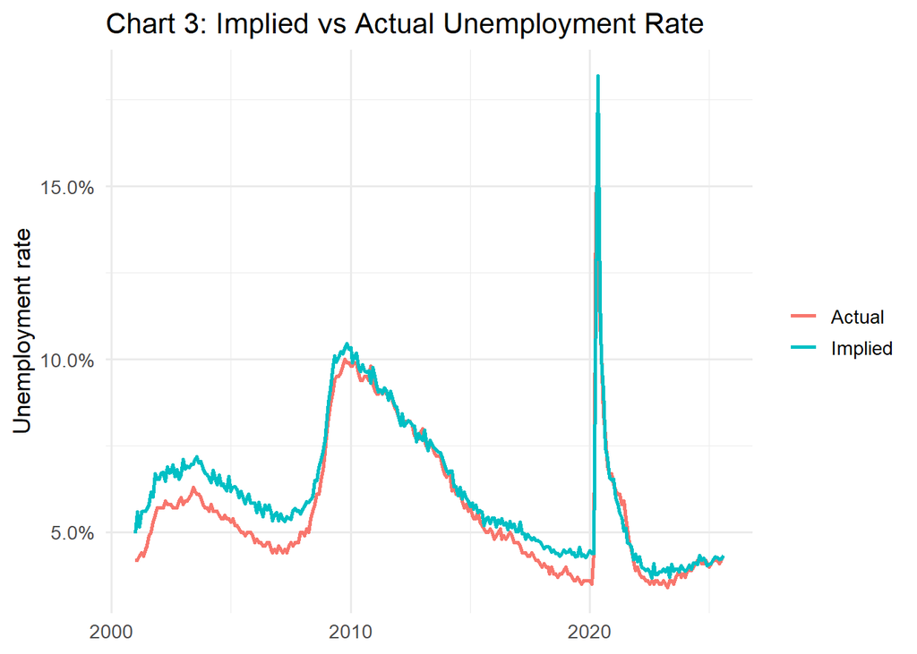

```r
# Convert each series to a data frame
u_df <- data.frame(date = index(UNRATE),   u_rate_pct = as.numeric(UNRATE))
s_df <- data.frame(date = index(JTSTSR),   s_rate_pct = as.numeric(JTSTSR))
U_df <- data.frame(date = index(UNEMPLOY), U_level    = as.numeric(UNEMPLOY))
v_df <- data.frame(date = index(JTSJOL),   V_level    = as.numeric(JTSJOL))

# Join the series together and construct unemployment dynamics
df <- u_df %>%
  inner_join(s_df, by = "date") %>%
  inner_join(U_df, by = "date") %>%
  inner_join(v_df, by = "date") %>%
  mutate(
    u_t = u_rate_pct/100,                         # unemployment rate as share
    s_t = s_rate_pct/100,                         # separation rate as share
    theta = V_level / U_level,                    # market tightness
    p_t = p_of_theta(theta, xi, alpha),           # job-finding rate from matching
    u_implied_next = u_t + s_t*(1-u_t) - p_t*u_t, # implied law of motion
    u_actual_next  = lead(u_t),                   # actual unemployment at t+1
    date_next      = lead(date)                   # align implied and actual
  ) %>%
  filter(!is.na(u_implied_next), !is.na(u_actual_next))

# Reshape for plotting
plot_df <- df %>%
  select(date_next, u_implied_next, u_actual_next) %>%
  rename(Implied = u_implied_next, Actual = u_actual_next) %>%
  pivot_longer(-date_next, names_to = "series", values_to = "value")

# Plot implied vs actual unemployment rate
ggplot(plot_df, aes(x = date_next, y = value, color = series)) +
  geom_line(linewidth = 0.9) +
  labs(
    title = "Chart 3: Implied vs Actual Unemployment Rate",
    x = NULL, y = "Unemployment rate"
  ) +
  scale_y_continuous(labels = scales::percent_format(accuracy = 0.1)) +
  theme_minimal(base_size = 13) +
  theme(legend.title = element_blank())
```